# Plasma cells SC mapping

Marc Elosua-Bayes

febrero 07, 2022

## Introduction

In this script we are going to map plasma cell subtypes onto the Visium slides.

## Libraries

```r
library(Seurat)
library(cowplot)
library(dplyr)
library(ggplot2)
library(SPOTlight)
```

## Setting parameters

Loading necessary paths and parameters

```r
set.seed(123)
source(here::here("misc/paths.R"))
source(here::here("utils/bin.R"))

"{plasma}/{plt_dir}" %>%
  glue::glue() %>%
  here::here() %>%
  dir.create(path = ,
             showWarnings = FALSE,
             recursive = TRUE)

"{plasma}/{robj_dir}" %>%
  glue::glue() %>%
  here::here() %>%
  dir.create(path = ,
             showWarnings = FALSE,
             recursive = TRUE)
```

Extract sample id and get Donor ID

```r
# sample_id <- params$sample_id
sample_id <- "esvq52_nluss5"
donor_id <- id_sp_df[id_sp_df$gem_id == sample_id, ] %>% dplyr::pull(donor_id)
```

## Load data

We have 4 different datasets that we are going to analyze separately. The spatial data comes from the script *03-clustering/03-clustering_integration.Rmd* while the sc data can be found in Ramon’s scRNAseq analysis: **/scratch/devel/rmassoni/tonsil_atlas_private/2-DOWNSTREAM_PROCESSING/results/R_objects/processed_seurat_objects/processed_seurat_objects/tonsil_integrated_with_harmony_scrublet_annotated.rds**.  
Plasma cell annotation comes from Sergio - **/scratch/devel/saguilar/PhD/PROJECTS/tonsil_atlas/tonsil_atlas_annotation/level_5/PC/data/delta/PC_seu_obj_level_5_delta.rds**

```r
sp_obj <- "{anot}/{robj_dir}/integrated_spatial_annot.rds" %>%
  glue::glue() %>%
  here::here() %>%
  readRDS(file = .)

# Single cell data
sc_obj <- "{myeloid}/{robj_dir}/tonsil_atlas_all_cells_20210930.rds" %>%
  glue::glue() %>%
  here::here() %>%
  readRDS(file = .)

# Plasma cell annotation
lvl5_obj <- "{plasma}/{robj_dir}/PC_seu_obj_level_5_delta.rds" %>%
  glue::glue() %>%
  here::here() %>%
  readRDS(file = .)
```

## Analysis

### Metadata

We are going to use SPOTlight to deconvolute the spatial spots and map the cell types.

We will start by adding the level5 definitive metadata labels to the full object.

```r
lvl5_metadata <- lvl5_obj@meta.data %>%
  dplyr::rename(annotation_plasma = names_level_5_clusters_delta) %>%
  dplyr::select(barcode, annotation_plasma)

pc_mature <- c("PC Mature IgA+", "PC Mature IgG+", "MBC-derived IgA+", "MBC-derived IgG+")

sc_obj@meta.data <- sc_obj@meta.data %>%
  # tibble::rownames_to_column("barcode") %>%
  dplyr::left_join(lvl5_metadata, by = "barcode") %>%
  dplyr::mutate(
    # Annotation for SPOTlight
    annotation_deconv = dplyr::if_else(
      is.na(annotation_plasma), annotation_level_1, annotation_plasma),
    annotation_deconv = dplyr::if_else(
      stringr::str_detect(
        string = annotation_deconv,
        # https://stackoverflow.com/questions/5671719/case-insensitive-search-of-a-list-in-r
        #  (?i) makes the regex case insensitive
        pattern = "(?i)prolif"),
      "Cycling", annotation_deconv),
    # Join populations of interest
    annotation_deconv = dplyr::case_when(
      stringr::str_detect(string = annotation_deconv, pattern = "LZ-derived early PC precursors") ~ "LZ-derived early PC precursors",
      stringr::str_detect(string = annotation_deconv, pattern = "LZ-derived IgG. PC precursor") ~ "LZ-derived IgG+ PC precursor",
      # stringr::str_detect(string = annotation_deconv, pattern = "PC Mature Ig") ~ "PC Mature IgG/A",
      annotation_deconv %in% pc_mature ~ "PC Mature IgG/A",
      # annotation_deconv %in% c("Early MBC-derived PC precursors", "MBC-derived PC precursors") ~ "(Early) MBC-derived PC precursors",
      TRUE ~ annotation_deconv)
    ) %>%
  # Remove cell types not of interest
  dplyr::filter(! annotation_deconv %in% c(
    "PC", "unknown", # Remove PC cells not annotated in Level 5 since they have been removed in the process
    "Short lived IgM PCs", "IGHV3-20/43 expressing PCs", "DZ migratory PC precursors ", # Remove very small populations
    "preBC", "preTC", # Remove populations not relevant for this step
    "GCBC"# Remove GCBC since we have LZ GCBC and DZ GCBC
    )) %>%
  # Remove cell types already present at level 5
  tibble::column_to_rownames("barcode")

table(sc_obj@meta.data$annotation_deconv)
```

```
##
##                           CD4_T                           csMBC                         Cycling                       Cytotoxic Early MBC-derived PC precursors                      epithelial                             FDC                    GC-DZ Bcells                    GC-LZ Bcells          …
##                           57985                             760                             997                            6074                             230                             361                            1203                             724                            1152          …
```

### Marker calculation

1st we need to determine the marker genes for each high-level cluster

```r
markers_lvl1_out <- "{plasma}/{robj_dir}/markers_lvl1_plasma.RDS" %>%
  glue::glue() %>%
  here::here()
file.remove(markers_lvl1_out)
```

```
## [1] TRUE
```

```r
if (file.exists(markers_lvl1_out)) {

  markers_lvl1 <- readRDS(file = markers_lvl1_out)

} else {
  #### Extract marker genes from each cluster ####
  Seurat::Idents(object = sc_obj) <- sc_obj@meta.data[, "annotation_level_1"]
  markers_lvl1 <- Seurat::FindAllMarkers(
    object = sc_obj,
    assay = "RNA",
    slot = "data",
    verbose = TRUE,
    only.pos = TRUE,
    max.cells.per.ident = 200)

  saveRDS(object = markers_lvl1, file = markers_lvl1_out)
}
DT::datatable(markers_lvl1, filter = "top")
```

|  | p_val | avg_log2FC | pct.1 | pct.2 | p_val_adj | cluster | gene |
| --- | --- | --- | --- | --- | --- | --- | --- |
| FTL | 7.83708557783318e-22 | 2.89982489408926 | 0.978 | 0.867 | 2.92934584728248e-17 | myeloid | FTL |
| TYROBP | 4.18753983771837e-21 | 2.28444010803879 | 0.359 | 0.02 | 1.56521864054237e-16 | myeloid | TYROBP |
| LYZ | 5.62909519341037e-21 | 4.21024983306952 | 0.448 | 0.049 | 2.10404320139293e-16 | myeloid | LYZ |
| CST3 | 1.53661818226309e-19 | 3.43965671184243 | 0.389 | 0.035 | 5.74357144166297e-15 | myeloid | CST3 |
| VIM | 4.08642806204481e-19 | 1.67033854494493 | 0.771 | 0.448 | 1.52742508103111e-14 | myeloid | VIM |
| FTH1 | 1.61644638325052e-18 | 2.43390123336803 | 0.972 | 0.82 | 6.04195329131381e-14 | myeloid | FTH1 |
| LGALS2 | 1.20318450382514e-16 | 2.07799170518755 | 0.322 | 0.018 | 4.4972630383976e-12 | myeloid | LGALS2 |
| CD68 | 3.01391141530956e-16 | 1.4099087997108 | 0.266 | 0.034 | 1.12653980881441e-11 | myeloid | CD68 |
| FCER1G | 3.45799074406645e-16 | 2.12637119035263 | 0.311 | 0.015 | 1.29252778031716e-11 | myeloid | FCER1G |
| MS4A6A | 2.17098787554852e-15 | 1.567287115625 | 0.249 | 0.01 | 8.11471848122527e-11 | myeloid | MS4A6A |

[output cut: 4152 more lines]

Now find the markers for plasma cells level 5 only between plasma cells

```r
markers_lvl5_out <- "{plasma}/{robj_dir}/markers_lvl5_plasma.RDS" %>%
  glue::glue() %>%
  here::here()
file.remove(markers_lvl5_out)
```

```
## [1] TRUE
```

```r
if (file.exists(markers_lvl5_out)) {

  markers_lvl5 <- readRDS(file = markers_lvl5_out)

} else {
  # lvl4 plasma cells lvl5_metadata
  lvl5_subs <- subset(
    sc_obj,
    # To level5 and consolidated cell types
    subset = annotation_deconv %in% c(
      unique(lvl5_metadata$annotation_plasma),  c("LZ-derived early PC precursors",
        "LZ-derived IgG+ PC precursor", "PC Mature IgG/A"))) # "(Early) MBC-derived PC precursors"
  #### Extract marker genes from each cluster ####
  Seurat::Idents(object = lvl5_subs) <- lvl5_subs@meta.data[, "annotation_deconv"]

  markers_lvl5 <- Seurat::FindAllMarkers(
    object = lvl5_subs,
    assay = "RNA",
    slot = "data",
    verbose = TRUE,
    only.pos = TRUE)

  saveRDS(object = markers_lvl5, file = markers_lvl5_out)
}
```

Join markers from both runs. Since we still want to keep the PC cells markers in the lower level markers we will add them to each one.

```r
# Keep markers for major cell types
# gene_vec <- c("BCL6", "PRDM1", "FDCSP")
markers_lvl1_sub <- markers_lvl1 %>% dplyr::filter(cluster != "PC") %>%
    dplyr::filter( ( avg_log2FC > 1 | pct.1 - pct.2 > 0.75) &
                   p_val_adj < 0.01 & pct.1 > 0.3) %>%
    # Remove ribosomal genes
    dplyr::filter(!stringr::str_detect(string = gene,
                                      pattern = "^RPS|^RPL"))
                   # | gene %in% gene_vec)

# Keep markers for general PC T cells
markers_lvl1_plasma <- markers_lvl1 %>%
  dplyr::filter(cluster == "PC") %>%
  # Filter to get PC specific markers
  # We are keeping those genes with a logFC > 1 or a pct.1 - pct.2 > 0.75 which
  # have a p_val_adj < 0.01 & pct.1 > 0.6 while keeping PC
  dplyr::filter( ( avg_log2FC > 1 | pct.1 - pct.2 > 0.75) &
                   p_val_adj < 0.01 & pct.1 > 0.6) %>%
  # Remove ribosomal genes
  dplyr::filter(!stringr::str_detect(string = gene, pattern = "^RPS|^RPL"))
```

Add general PC cell markers to the specific cell types

```r
markers_lvl5_update <- lapply(as.character(unique(markers_lvl5$cluster)), function (i) {
  # Filter level 5 clusters
  tmp <- markers_lvl5 %>%
  #   dplyr::filter(avg_log2FC > 0.75 | pct.1 - pct.2 > 0.4) %>%
    dplyr::filter(cluster == i) %>%
    # Remove ribosomal genes
    dplyr::filter(!stringr::str_detect(string = gene,
                                      pattern = "^RPS|^RPL"))

  # Add general PC markers
  tmp %>%
    dplyr::bind_rows(markers_lvl1_plasma) %>%
    dplyr::mutate(cluster = i)
}) %>%
  dplyr::bind_rows()
```

Combine level-1 and level-5 markers

```r
all_markers <- dplyr::bind_rows(markers_lvl1_sub, markers_lvl5_update) %>%
  dplyr::arrange(dplyr::desc(avg_log2FC)) %>%
  dplyr::group_by(cluster, gene) %>%
  dplyr::filter(dplyr::row_number() == 1)
```

Subset SC object so all the cells from the same cell type to come from the same batch

```r
# subset most representative sample(s)
ns <- with(sc_obj@meta.data, table(gem_id, annotation_deconv))
ns <- as.matrix(unclass(ns))
m <- 100 # Max cells per cell type
# Extract cell barcodes
meta <- sc_obj@meta.data

id <- lapply(colnames(ns), function(nm) {
    x <- ns[, nm]
    # Initialize variables
    n <- 0    # N of cells
    s <- c()  # Gem IDs
    b <- c()  # Cell barcodes
    while (n < m & length(x) > 0) {
        # select gem id with the most cells
        i <- names(sort(x, decreasing = TRUE))[[1]]
        # Add gem id to vector s
        s <- c(s, i)
        # Add number of cells per cell type to n
        n <- n + x[[i]]
        # Remove gem id from x to move on to the next
        x <- x[names(x) != i]
        # extract barcode
        barcode <- rownames(meta[meta[, "gem_id"] == i &
                            meta[, "annotation_deconv"] == nm, ])
        # make sure it adds up to m
        # print(barcode)
        if ((length(b) + length(barcode)) > m) {
          barcode <- sample(x = barcode, size = m - length(b), replace = FALSE)
        }
        b <- c(b, barcode)  # Cell barcodes
    }
    return(b)
})

sc_sub <- sc_obj[, unlist(id)]
table(sc_sub@meta.data$annotation_deconv)
```

```
##
##                           CD4_T                           csMBC                         Cycling                       Cytotoxic Early MBC-derived PC precursors                      epithelial                             FDC                    GC-DZ Bcells                    GC-LZ Bcells          …
##                             100                             100                             100                             100                             100                             100                             100                             100                             100          …
```

## Save data

```r
decon_fn <- "{plasma}/{robj_dir}/spotlight_ls_plasma.rds" %>%
  glue::glue() %>%
  here::here()
# if (! file.exists(decon_fn) ) {
saveRDS(
  object = spotlight_ls,
  file = decon_fn)
# } else {
#   spotlight_ls <- readRDS(file = here::here(glue::glue("{plasma}/{robj_dir}/spotlight_ls_plasma.rds")))
# }
```

3rd Check Topic profiles

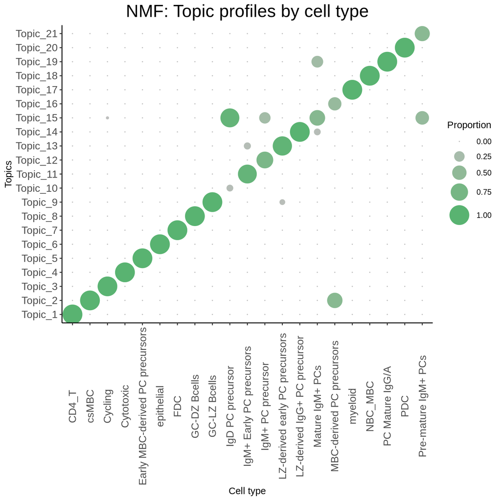

```r
nmf_mod_ls <- spotlight_ls[[1]]
nmf_mod <- nmf_mod_ls[[1]]

h <- NMF::coef(nmf_mod)
rownames(h) <- paste("Topic", 1:nrow(h), sep = "_")
topic_profile_plts <- SPOTlight::dot_plot_profiles_fun(
  h = h,
  train_cell_clust = nmf_mod_ls[[2]])

topic_profile_plts[[2]] +
  ggplot2::theme(axis.text.x = ggplot2::element_text(angle = 90),
                 axis.text = ggplot2::element_text(size = 12))
```

## Visualize deconvolution results

```r
decon_mtrx <- spotlight_ls[[2]]
decon_mtrx <- decon_mtrx[, colnames(decon_mtrx) != "res_ss"]

# Set as 0 cell types predicted to be under 1 % of the spot
# decon_mtrx[decon_mtrx < 0.03] <- 0
```

Change column names

```r
nm_df <- data.frame(
  mod_nm = stringr::str_replace_all(string = unique(all_markers$cluster),
                                    pattern = "[[:punct:]]|\\s|\\+" ,
                                    replacement = "."),
  plt_nm = unique(all_markers$cluster)
  )

# Save nm_df
"{plasma}/{robj_dir}/plasma_nm_df.rds" %>%
  glue::glue() %>%
  here::here() %>%
  saveRDS(
    object = nm_df,
    file = .)


new_cn <- data.frame(mod_nm = colnames(decon_mtrx)) %>%
  dplyr::left_join(nm_df, by = "mod_nm") %>%
  # Central.Mem.PASK. fives some trouble because it only changes between + an -
  # negative goes first and distinct solves it automatically
  dplyr::distinct() %>%
  dplyr::pull(plt_nm)

colnames(decon_mtrx) <- new_cn
```

We are going to add the deconvolution to the Seurat object.

```r
metadata <- cbind(sp_obj@meta.data, decon_mtrx)
sp_obj@meta.data <- metadata
```

Look at cells topic profile

```r
basis_spotlight <- data.frame(NMF::basis(spotlight_ls[[1]][[1]]))

train_labs <- spotlight_ls[[1]][[2]]
colnames(basis_spotlight) <- unique(stringr::str_wrap(train_labs, width = 30))

basis_spotlight[basis_spotlight < 0.0000001] <- 0

DT::datatable(basis_spotlight, filter = "top")
```

|  | CD4_T | csMBC | Cycling | Cytotoxic | Early MBC-derived PC precursors | epithelial | FDC | GC-DZ Bcells | GC-LZ Bcells | IgD PC precursor | IgM+ Early PC precursors | IgM+ PC precursor | LZ-derived early PC precursors | LZ-derived IgG+ PC precursor | Mature IgM+ PCs | MBC-derived PC precursors | myeloid | NBC_MBC | PC Mature IgG/A | PDC | Pre-mature IgM+ PCs |
| --- | --- | --- | --- | --- | --- | --- | --- | --- | --- | --- | --- | --- | --- | --- | --- | --- | --- | --- | --- | --- | --- |
| S100A9 | 0 | 0 | 0 | 0 | 0 | 0.00118046453458983 | 0 | 0 | 0 | 0 | 0 | 0 | 0 | 0 | 0 | 0 | 0.000308537581622453 | 0 | 0 | 0 | 0 |
| S100A8 | 0 | 0 | 0 | 0 | 0 | 0.00121020953140033 | 0 | 0 | 0 | 0 | 0 | 0 | 0 | 0 | 0 | 0 | 0.000313121538846937 | 0 | 0 | 0 | 0 |
| IGHA2 | 0 | 0.000294772257095201 | 0 | 0 | 0 | 0 | 0 | 0 | 0 | 0 | 0 | 0 | 0 | 0 | 0 | 0 | 0 | 0 | 0.000805218247863782 | 0 | 0 |
| IGHV3-15 | 0 | 0 | 0 | 0 | 0 | 0 | 0 | 0 | 0 | 0 | 0 | 0 | 0 | 9.6771039450685e-05 | 0 | 0 | 0 | 0 | 0.000478374675295775 | 0 | 0.000282033041649787 |
| IGLC1 | 0 | 0 | 0 | 0 | 0 | 0 | 0 | 0 | 0 | 0 | 0 | 0 | 0 | 0.000368082970303883 | 0.000134159260762002 | 0 | 0 | 0 | 0.000767828622541486 | 0 | 0.000147947795811219 |
| IGHD | 0 | 0 | 0 | 0 | 0 | 0 | 0 | 0 | 0 | 0.000268219331777737 | 0 | 0 | 0 | 0 | 0.000932824157255646 | 0 | 0 | 0 | 0 | 0 | 0 |
| LYZ | 0 | 0 | 0 | 0 | 0 | 0.00067203474291122 | 0 | 0 | 0 | 0 | 0 | 0 | 0 | 0 | 0 | 0 | 0.000703040992670986 | 0 | 0 | 0 | 0 |
| IGHV3-7 | 0 | 0 | 0 | 0 | 0 | 0 | 0 | 0 | 0 | 0 | 0 | 4.4454545933623e-05 | 0 | 0 | 0 | 2.2066125301449e-05 | 0 | 0 | 0.000864717699603599 | 0 | 0 |
| G0S2 | 0 | 0 | 0 | 0 | 0 | 0 | 1.31502404023986e-05 | 0 | 0 | 0 | 0 | 0 | 0 | 0 | 0 | 0 | 0.000886232655888412 | 0 | 0 | 0 | 0 |
| IGKV3-20 | 0 | 0 | 0 | 0 | 0 | 0 | 0 | 0 | 0 | 0 | 0 | 0 | 0 | 0.000797546807717756 | 0 | 0 | 0 | 0 | 0 | 0 | 0 |

[output cut: 7118 more lines]